# Project1 task2 Parameter Exploration

## R Markdown

We will consider the model $f_5(x,a_0,a_1,a_2)= (a_0+ a_1x)e^{-a_2x}$ and how changing the parameters of those models changes the output.

We set $a_0=-1$ and $a_2=0.001$ and look at the effect of changing a1. In the figure below, the left plot $a_1=0.1$ and in the right plot $a_1=0.01$. For this choice of parameter values, left plot has more steep figure

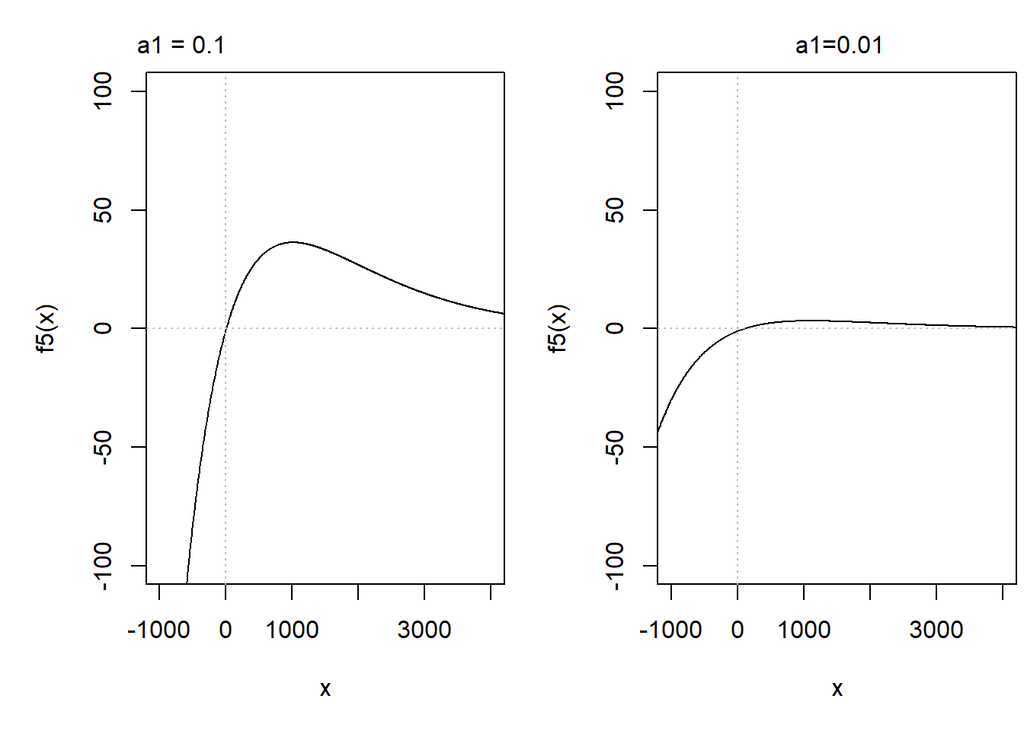

```r
x <- seq(-3000,10000,5)

f5 <- function(x,a0=-1,a1=0.1,a2=0.001){
  (a0 + a1*x)*exp(-1*a2*x)
}
y1 <- f5(x,-1,0.1,0.001)
y2 <- f5(x,-1,0.01,0.001)


par(mfrow=c(1,2),mar=c(5,5,0.5,0.25),oma=c(0,0,2,0))
plot(x,y1,xlim=c(-1000,4000),ylim=c(-100,100),type='l',xlab="x",ylab='f5(x)')
abline(h=0,lty=3,col='gray')
abline(v=0,lty=3,col='gray')
plot(x,y2,xlim=c(-1000,4000),ylim=c(-100,100),type='l',xlab="x",ylab='f5(x)')
abline(h=0,lty=3,col='gray')
abline(v=0,lty=3,col='gray')
mtext('a1 = 0.1                                                                                   a1=0.01',outer=TRUE)
```

As we look at these two chart, while a1 is closer to 0, the plot will look flatter.

Let`s look at another function. $f_4(x,a_0,a_1,a_2)= a_0+a_1x+a_2ln(0.005x+1)$ and how changing the parameters of those models changes the output.

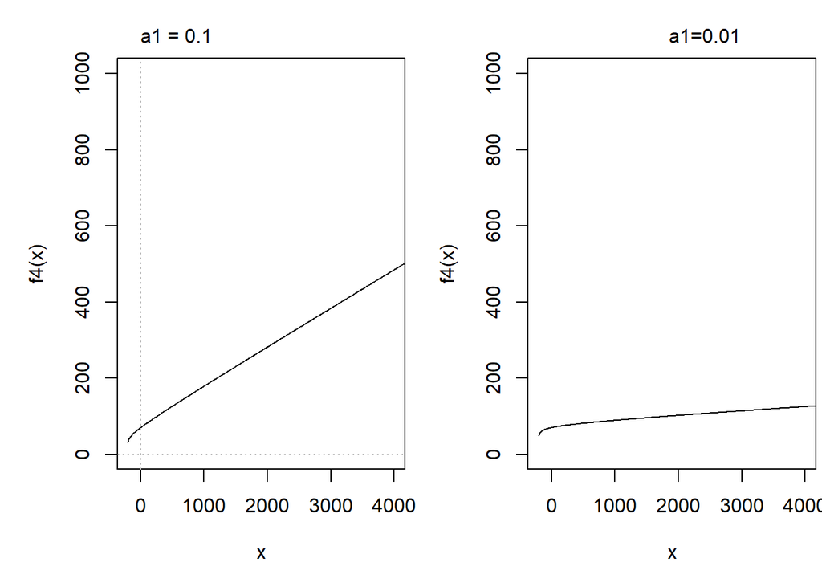

```r
x <- seq(-200,10000,5)

f4 <- function(x,a=70,b=0.1,c=5){
  a+b*x+c*log(0.005*x+1)
}
y1 <- f4(x,70,0.1,5)
y2 <- f4(x,70,0.01,5)


par(mfrow=c(1,2),mar=c(5,5,0.5,0.25),oma=c(0,0,2,0))
plot(x,y1,xlim=c(-200,4000),ylim=c(0,1000),type='l',xlab="x",ylab='f4(x)')
abline(h=0,lty=3,col='gray')
abline(v=0,lty=3,col='gray')
plot(x,y2,xlim=c(-200,4000),ylim=c(0,1000),type='l',xlab="x",ylab='f4(x)')

mtext('           a1 = 0.1                                                                                   a1=0.01',outer=TRUE)
```